# Sample - Summary - Homework

Jose Rico

April 13, 2020

## Assignment Overview

This will be your summative assignment for the sampling unit. You will be;

- conducting a simulation
- analyzing the simulations with statistics and visualizations
- constructing confidence intervals

## Assignment Scenario

We will be analyzing a particular game, the rolling of three dice. A winning rolls is when you get at least a match of two die faces. For example; 1,1,4 would be a winning roll. 1,2,3 would be a losing roll.

## Constructing a population data frame

Simulate rolling 100,000 times

```r
set.seed(1123581321)
roll1 = sample(1:6,100000, replace=T)
roll2 = sample(1:6,100000, replace=T)
roll3 = sample(1:6,100000, replace=T)
roll_sim_population <- data.frame(roll1, roll2, roll3) %>%
  mutate(win = if_else(roll1==roll2 | roll1==roll3 | roll2==roll3, TRUE, FALSE))
```

## Assignment Tasks

### Sampling/Analysis/Narratives for different sample sizes

1. Take 1000 samples for each sample size 25, 100 and 400.

#### Taking 1000 samples, for n= 25, 100, 400

```r
set.seed(1123581321)
samples_n25_reps1000 <- roll_sim_population %>%
        rep_sample_n(size = 25, reps = 1000, replace = F)

samples_n100_reps1000 <- roll_sim_population %>%
        rep_sample_n(size = 100, reps = 1000, replace = F)

samples_n400_reps1000 <- roll_sim_population %>%
        rep_sample_n(size = 400, reps = 1000, replace = F)
```

2. Construct sampling distributions histograms for sample size = 25.

#### Calculate Summary Statistics for Each Sample (n=25)

```r
summary_n25_reps1000 <- samples_n25_reps1000 %>%

          group_by(replicate) %>%

          summarize(win = sum(win == "TRUE")) %>%

          mutate(prop_win = win/25)  #### need to change divisor to match the sample size
```

#### Create histogram for distribution of 1000 samples for sample size (n=25).

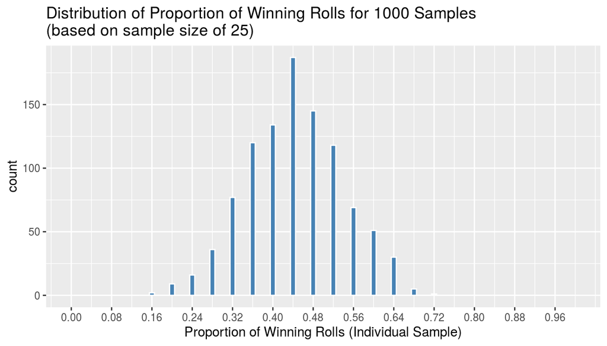

```r
summary_n25_reps1000 %>%

  ggplot(aes(prop_win)) +

  geom_histogram(binwidth = 0.01,
                 color="white",
                 fill="steelblue") +

  labs(x = "Proportion of Winning Rolls (Individual Sample)",
       title ="Distribution of Proportion of Winning Rolls for 1000 Samples \n(based on sample size of 25)") +


    scale_x_continuous(limits = c(0, 1), breaks = seq(0,1,0.08))
```

2. Construct sampling distributions histograms for sample size = 100.

#### Calculate Summary Statistics for Each Sample (n=100)

```r
summary_n100_reps1000 <- samples_n100_reps1000 %>%

          group_by(replicate) %>%

          summarize(win = sum(win == "TRUE")) %>%

          mutate(prop_win = win/100)  #### need to change divisor to match the sample size
```

#### Create histogram for distribution of 1000 samples for sample size (n=100).

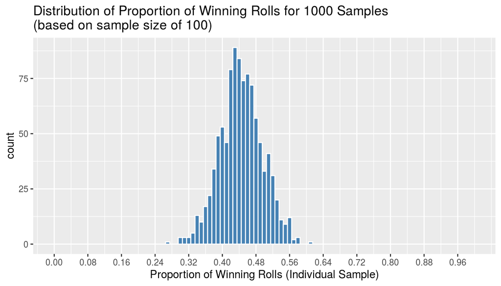

```r
summary_n100_reps1000 %>%

  ggplot(aes(prop_win)) +

  geom_histogram(binwidth = 0.01,
                 color="white",
                 fill="steelblue") +

  labs(x = "Proportion of Winning Rolls (Individual Sample)",
       title ="Distribution of Proportion of Winning Rolls for 1000 Samples \n(based on sample size of 100)") +


    scale_x_continuous(limits = c(0, 1), breaks = seq(0,1,0.08))
```

```r
n25_dist_mean = mean(summary_n25_reps1000$prop_win)
n25_dist_sd = round(sd(summary_n25_reps1000$prop_win),3)
n25_bottom_2.5 = quantile(summary_n25_reps1000$prop_win,0.025)
n25_top_2.5 = quantile(summary_n25_reps1000$prop_win,0.975)

n100_dist_mean = mean(summary_n100_reps1000$prop_win)
n100_dist_sd = round(sd(summary_n100_reps1000$prop_win),3)
n100_bottom_2.5 = quantile(summary_n100_reps1000$prop_win,0.025)
n100_top_2.5 = quantile(summary_n100_reps1000$prop_win,0.975)
```

### Table of Statistics for Sampling Distributions

| sample size | mean | sd | bottom_2.5 | top_2.5 |
| --- | --- | --- | --- | --- |
| 25 | 0.44328 | 0.096 | 0.24 | 0.64 |
| 100 | 0.44508 | 0.051 | 0.34 | 0.55 |

#### Take a sample of size 25 from our population

```r
set.seed(1123581321)
sample_n25 <- roll_sim_population %>%
  sample_n(size = 25, replace = F )
```

#### Construct CI for single sample of n=25

```r
binom.test(~(win == "TRUE"), conf.level = 0.95, ci.method= "Wald", data = sample_n25) %>%
  confint() %>%
    kable() %>%
  kable_styling(bootstrap_options = "striped", full_width = F, position = "left")
```

| probability of success | lower | upper | level |
| --- | --- | --- | --- |
| 0.4 | 0.2079635 | 0.5920365 | 0.95 |